# INN Hotels Project

#### Checking model performance on test set

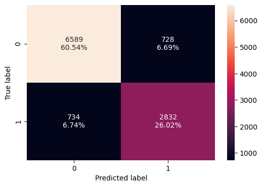

```python
confusion_matrix_sklearn(model, X_test, y_test)
```

```python
decision_tree_tune_perf_test = model_performance_classification_sklearn(model, X_test, y_test)
decision_tree_tune_perf_test
```

|  | Accuracy | Recall | Precision | F1 |
| --- | --- | --- | --- | --- |
| 0 | 0.86566 | 0.79417 | 0.79551 | 0.79484 |

**Before pruning the tree let's check the important features.**

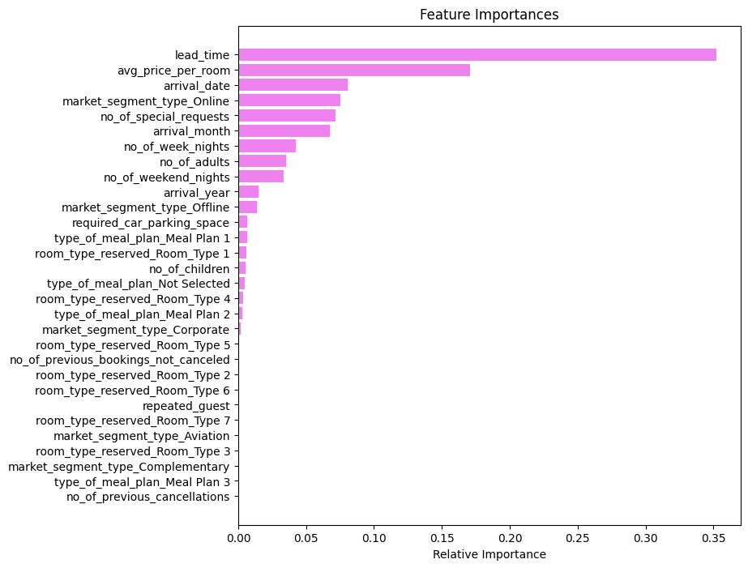

```python
feature_names = list(X_train.columns)
importances = model.feature_importances_
indices = np.argsort(importances)

plt.figure(figsize=(8, 8))
plt.title("Feature Importances")
plt.barh(range(len(indices)), importances[indices], color="violet", align="center")
plt.yticks(range(len(indices)), [feature_names[i] for i in indices])
plt.xlabel("Relative Importance")
plt.show()
```

#### Pruning the tree

```python
# Choose the type of classifier.
estimator = DecisionTreeClassifier(random_state=1, class_weight="balanced")

# Grid of parameters to choose from
parameters = {
    "max_depth": np.arange(2, 7, 2),
    "max_leaf_nodes": [50, 75, 150, 250],
    "min_samples_split": [10, 30, 50, 70],
}

# Type of scoring used to compare parameter combinations
acc_scorer = make_scorer(f1_score)

# Run the grid search
grid_obj = GridSearchCV(estimator, parameters, scoring=acc_scorer, cv=5)
grid_obj = grid_obj.fit(X_train, y_train)

# Set the clf to the best combination of parameters
estimator = grid_obj.best_estimator_

# Fit the best algorithm to the data.
estimator.fit(X_train, y_train)
```

```
DecisionTreeClassifier(class_weight='balanced', max_depth=np.int64(6),
                       max_leaf_nodes=50, min_samples_split=70, random_state=1)
```

#### Checking performance on training set

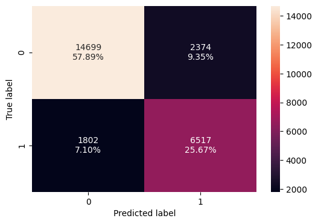

```python
confusion_matrix_sklearn(estimator, X_train, y_train)
```

```python
decision_tree_tune_perf_train = model_performance_classification_sklearn(
    estimator, X_train, y_train
)
decision_tree_tune_perf_train
```

|  | Accuracy | Recall | Precision | F1 |
| --- | --- | --- | --- | --- |
| 0 | 0.83554 | 0.78339 | 0.73299 | 0.75735 |

```python
decision_tree_perf_test = model_performance_classification_sklearn(
    estimator, X_test, y_test
)
decision_tree_perf_test
```

|  | Accuracy | Recall | Precision | F1 |
| --- | --- | --- | --- | --- |
| 0 | 0.83212 | 0.76921 | 0.73205 | 0.75017 |

#### Visualizing the Decision Tree

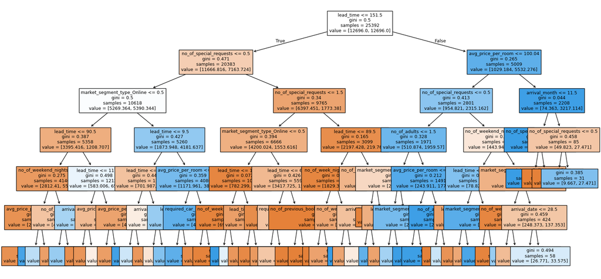

```python
plt.figure(figsize=(20, 10))
out = tree.plot_tree(
    estimator,
    feature_names=feature_names,
    filled=True,
    fontsize=9,
    node_ids=False,
    class_names=None,
)
# below code will add arrows to the decision tree split if they are missing
for o in out:
    arrow = o.arrow_patch
    if arrow is not None:
        arrow.set_edgecolor("black")
        arrow.set_linewidth(1)
plt.show()
```

```python
print(tree.export_text(estimator, feature_names=feature_names, show_weights=True))
```

```
|--- lead_time <= 151.50
|   |--- no_of_special_requests <= 0.50
|   |   |--- market_segment_type_Online <= 0.50
|   |   |   |--- lead_time <= 90.50
|   |   |   |   |--- no_of_weekend_nights <= 1.50
|   |   |   |   |   |--- avg_price_per_room <= 202.00
|   |   |   |   |   |   |--- weights: [2356.56, 293.02] class: 0
|   |   |   |   |   |--- avg_price_per_room >  202.00
|   |   |   |   |   |   |--- weights: [1.49, 21.37] class: 1
|   |   |   |   |--- no_of_weekend_nights >  1.50
|   |   |   |   |   |--- no_of_adults <= 1.50
|   |   |   |   |   |   |--- weights: [104.11, 157.19] class: 1
|   |   |   |   |   |--- no_of_adults >  1.50
|   |   |   |   |   |   |--- weights: [350.25, 83.94] class: 0
|   |   |   |--- lead_time >  90.50
|   |   |   |   |--- lead_time <= 117.50
|   |   |   |   |   |--- arrival_month <= 10.50
|   |   |   |   |   |   |--- weights: [245.40, 512.78] class: 1
|   |   |   |   |   |--- arrival_month >  10.50
|   |   |   |   |   |   |--- weights: [43.13, 4.58] class: 0
|   |   |   |   |--- lead_time >  117.50
|   |   |   |   |   |--- avg_price_per_room <= 89.88
|   |   |   |   |   |   |--- weights: [169.55, 27.47] class: 0
|   |   |   |   |   |--- avg_price_per_room >  89.88
|   |   |   |   |   |   |--- weights: [124.93, 108.36] class: 0
|   |   |--- market_segment_type_Online >  0.50
|   |   |   |--- lead_time <= 9.50
|   |   |   |   |--- lead_time <= 2.50
|   |   |   |   |   |--- avg_price_per_room <= 202.67
|   |   |   |   |   |   |--- weights: [408.25, 93.09] class: 0
|   |   |   |   |   |--- avg_price_per_room >  202.67
|   |   |   |   |   |   |--- weights: [0.74, 16.79] class: 1
|   |   |   |   |--- lead_time >  2.50
|   |   |   |   |   |--- arrival_month <= 9.50
|   |   |   |   |   |   |--- weights: [171.03, 228.92] class: 1
|   |   |   |   |   |--- arrival_month >  9.50
|   |   |   |   |   |   |--- weights: [121.96, 21.37] class: 0
|   |   |   |--- lead_time >  9.50
|   |   |   |   |--- avg_price_per_room <= 105.27
|   |   |   |   |   |--- lead_time <= 25.50
```

[output cut: 93 more lines]

```
|   |   |   |   |   |--- arrival_date <= 28.50
|   |   |   |   |   |   |--- weights: [221.60, 103.78] class: 0
|   |   |   |   |   |--- arrival_date >  28.50
|   |   |   |   |   |   |--- weights: [26.77, 33.58] class: 1
|   |--- avg_price_per_room >  100.04
|   |   |--- arrival_month <= 11.50
|   |   |   |--- no_of_special_requests <= 2.50
|   |   |   |   |--- weights: [0.00, 3189.64] class: 1
|   |   |   |--- no_of_special_requests >  2.50
|   |   |   |   |--- weights: [24.54, 0.00] class: 0
|   |   |--- arrival_month >  11.50
|   |   |   |--- no_of_special_requests <= 0.50
|   |   |   |   |--- weights: [40.16, 0.00] class: 0
|   |   |   |--- no_of_special_requests >  0.50
|   |   |   |   |--- weights: [9.67, 27.47] class: 1
```

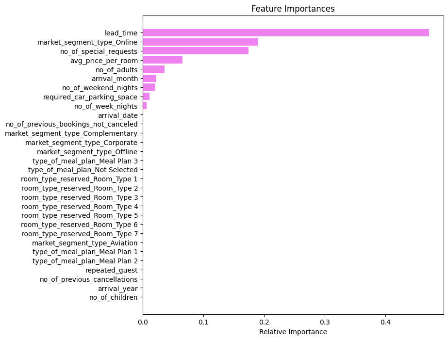

```python
# importance of features in the tree building

importances = estimator.feature_importances_
indices = np.argsort(importances)

plt.figure(figsize=(8, 8))
plt.title("Feature Importances")
plt.barh(range(len(indices)), importances[indices], color="violet", align="center")
plt.yticks(range(len(indices)), [feature_names[i] for i in indices])
plt.xlabel("Relative Importance")
plt.show()
```

**Cost Complexity Pruning**

```python
clf = DecisionTreeClassifier(random_state=1, class_weight="balanced")
path = clf.cost_complexity_pruning_path(X_train, y_train)
ccp_alphas, impurities = abs(path.ccp_alphas), path.impurities

print(ccp_alphas)
print(impurities)
```

```
[0.00000000e+00 8.13151629e-20 0.00000000e+00 ... 1.25315255e-02
 3.40462280e-02 8.20593806e-02]
[0.00833143 0.00833143 0.00833143 ... 0.34984816 0.41794062 0.5       ]
```

```python
pd.DataFrame(path)
```

|  | ccp_alphas | impurities |
| --- | --- | --- |
| 0 | 0.00000 | 0.00833 |
| 1 | -0.00000 | 0.00833 |
| 2 | 0.00000 | 0.00833 |
| 3 | 0.00000 | 0.00833 |
| 4 | 0.00000 | 0.00833 |
| ... | ... | ... |
| 1618 | 0.00938 | 0.32791 |
| 1619 | 0.00941 | 0.33732 |
| 1620 | 0.01253 | 0.34985 |
| 1621 | 0.03405 | 0.41794 |
| 1622 | 0.08206 | 0.50000 |

1623 rows × 2 columns

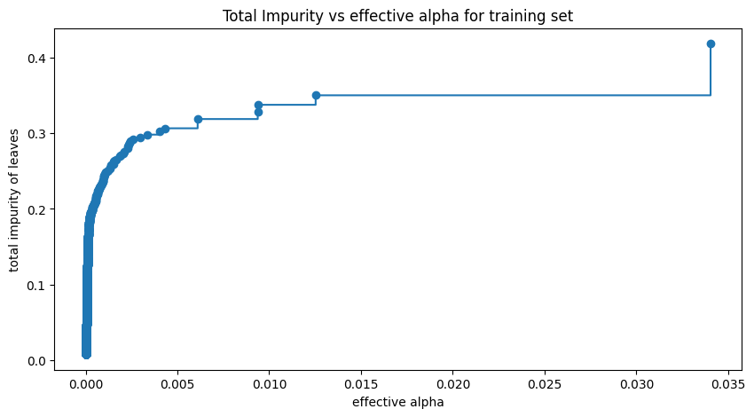

```python
fig, ax = plt.subplots(figsize=(10, 5))
ax.plot(ccp_alphas[:-1], impurities[:-1], marker="o", drawstyle="steps-post")
ax.set_xlabel("effective alpha")
ax.set_ylabel("total impurity of leaves")
ax.set_title("Total Impurity vs effective alpha for training set")
plt.show()
```

Next, we train a decision tree using effective alphas. The last value in `ccp_alphas` is the alpha value that prunes the whole tree, leaving the tree, `clfs[-1]`, with one node.

```python
clfs = []
for ccp_alpha in ccp_alphas:
    clf = DecisionTreeClassifier(
        random_state=1, ccp_alpha=ccp_alpha, class_weight="balanced"
    )
    clf.fit(X_train, y_train)
    clfs.append(clf)
print(
    "Number of nodes in the last tree is: {} with ccp_alpha: {}".format(
        clfs[-1].tree_.node_count, ccp_alphas[-1]
    )
)
```

```
Number of nodes in the last tree is: 1 with ccp_alpha: 0.08205938055990486
```

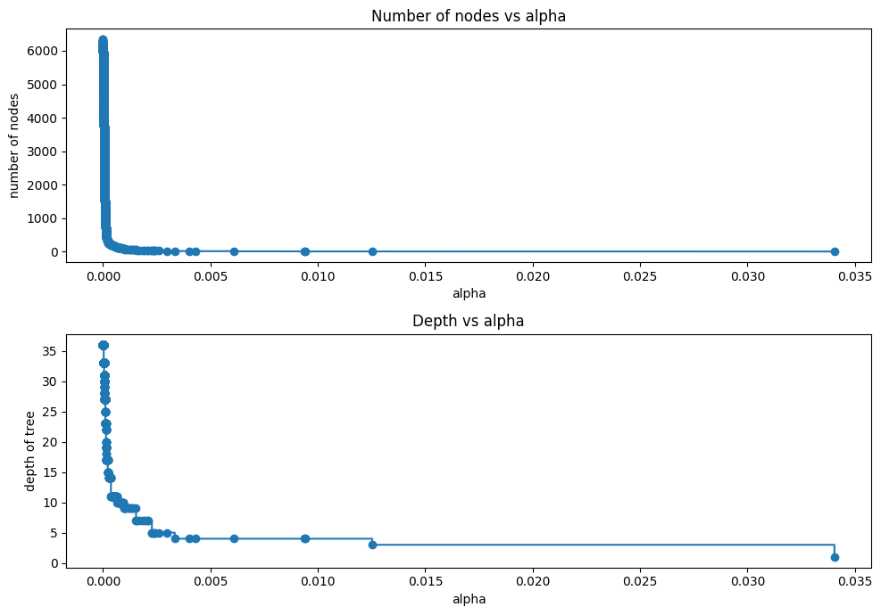

```python
clfs = clfs[:-1]
ccp_alphas = ccp_alphas[:-1]

node_counts = [clf.tree_.node_count for clf in clfs]
depth = [clf.tree_.max_depth for clf in clfs]
fig, ax = plt.subplots(2, 1, figsize=(10, 7))
ax[0].plot(ccp_alphas, node_counts, marker="o", drawstyle="steps-post")
ax[0].set_xlabel("alpha")
ax[0].set_ylabel("number of nodes")
ax[0].set_title("Number of nodes vs alpha")
ax[1].plot(ccp_alphas, depth, marker="o", drawstyle="steps-post")
ax[1].set_xlabel("alpha")
ax[1].set_ylabel("depth of tree")
ax[1].set_title("Depth vs alpha")
fig.tight_layout()
```

#### F1 Score vs alpha for training and testing sets

```python
f1_train = []
for clf in clfs:
    pred_train = clf.predict(X_train)
    values_train = f1_score(y_train, pred_train)
    f1_train.append(values_train)

f1_test = []
for clf in clfs:
    pred_test = clf.predict(X_test)
    values_test = f1_score(y_test, pred_test)
    f1_test.append(values_test)
```

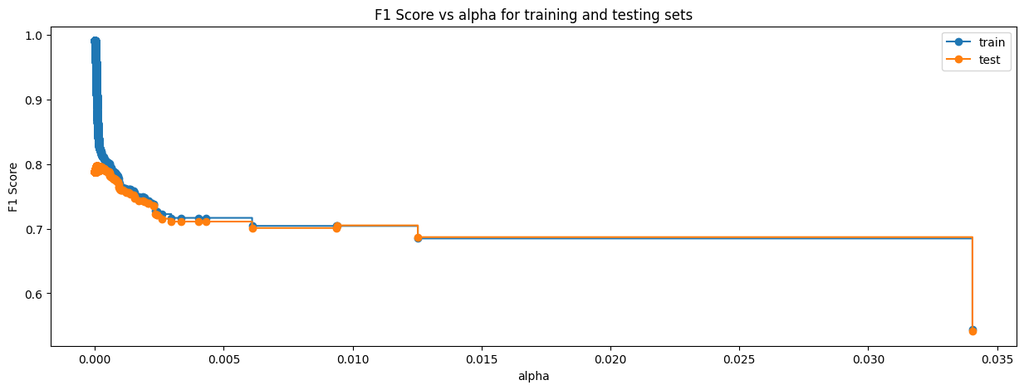

```python
fig, ax = plt.subplots(figsize=(15, 5))
ax.set_xlabel("alpha")
ax.set_ylabel("F1 Score")
ax.set_title("F1 Score vs alpha for training and testing sets")
ax.plot(ccp_alphas, f1_train, marker="o", label="train", drawstyle="steps-post")
ax.plot(ccp_alphas, f1_test, marker="o", label="test", drawstyle="steps-post")
ax.legend()
plt.show()
```

```python
index_best_model = np.argmax(f1_test)
best_model = clfs[index_best_model]
print(best_model)
```

```
DecisionTreeClassifier(ccp_alpha=np.float64(9.254702019625533e-05),
                       class_weight='balanced', random_state=1)
```

#### Checking performance on training set

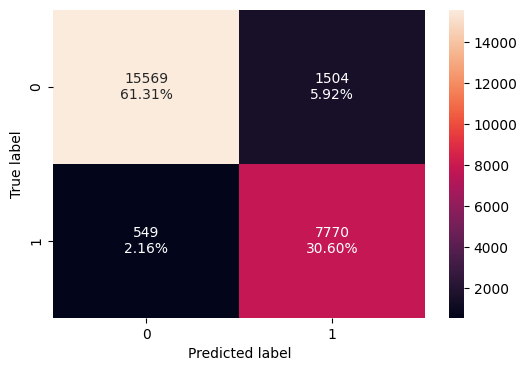

```python
confusion_matrix_sklearn(best_model, X_train, y_train)
```

```python
decision_tree_post_perf_train = model_performance_classification_sklearn(
    best_model, X_train, y_train
)
decision_tree_post_perf_train
```

|  | Accuracy | Recall | Precision | F1 |
| --- | --- | --- | --- | --- |
| 0 | 0.91915 | 0.93401 | 0.83783 | 0.88331 |

#### Checking performance on test set

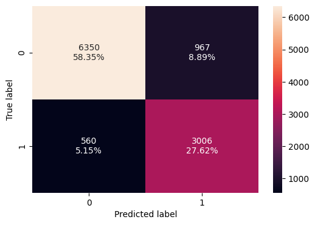

```python
confusion_matrix_sklearn(best_model, X_test, y_test)
```

```python
decision_tree_post_perf_test = model_performance_classification_sklearn(best_model, X_test, y_test)
decision_tree_post_perf_test
```

|  | Accuracy | Recall | Precision | F1 |
| --- | --- | --- | --- | --- |
| 0 | 0.85969 | 0.84296 | 0.75661 | 0.79745 |

[figure not shown]

```python
plt.figure(figsize=(20, 10))

out = tree.plot_tree(
    best_model,
    feature_names=feature_names,
    filled=True,
    fontsize=9,
    node_ids=False,
    class_names=None,
)
for o in out:
    arrow = o.arrow_patch
    if arrow is not None:
        arrow.set_edgecolor("black")
        arrow.set_linewidth(1)
plt.show()
```

```python
# Text report showing the rules of a decision tree -

print(tree.export_text(best_model, feature_names=feature_names, show_weights=True))
```

```
|--- lead_time <= 151.50
|   |--- no_of_special_requests <= 0.50
|   |   |--- market_segment_type_Online <= 0.50
|   |   |   |--- lead_time <= 90.50
|   |   |   |   |--- no_of_weekend_nights <= 1.50
|   |   |   |   |   |--- avg_price_per_room <= 202.00
|   |   |   |   |   |   |--- no_of_weekend_nights <= 0.50
|   |   |   |   |   |   |   |--- market_segment_type_Offline <= 0.50
|   |   |   |   |   |   |   |   |--- repeated_guest <= 0.50
|   |   |   |   |   |   |   |   |   |--- avg_price_per_room <= 87.25
|   |   |   |   |   |   |   |   |   |   |--- market_segment_type_Corporate <= 0.50
|   |   |   |   |   |   |   |   |   |   |   |--- weights: [54.29, 0.00] class: 0
|   |   |   |   |   |   |   |   |   |   |--- market_segment_type_Corporate >  0.50
|   |   |   |   |   |   |   |   |   |   |   |--- truncated branch of depth 6
|   |   |   |   |   |   |   |   |   |--- avg_price_per_room >  87.25
|   |   |   |   |   |   |   |   |   |   |--- lead_time <= 1.50
|   |   |   |   |   |   |   |   |   |   |   |--- weights: [38.67, 1.53] class: 0
|   |   |   |   |   |   |   |   |   |   |--- lead_time >  1.50
|   |   |   |   |   |   |   |   |   |   |   |--- truncated branch of depth 5
|   |   |   |   |   |   |   |   |--- repeated_guest >  0.50
|   |   |   |   |   |   |   |   |   |--- weights: [130.88, 0.00] class: 0
|   |   |   |   |   |   |   |--- market_segment_type_Offline >  0.50
|   |   |   |   |   |   |   |   |--- weights: [1226.99, 1.53] class: 0
|   |   |   |   |   |   |--- no_of_weekend_nights >  0.50
|   |   |   |   |   |   |   |--- lead_time <= 65.50
|   |   |   |   |   |   |   |   |--- avg_price_per_room <= 116.02
|   |   |   |   |   |   |   |   |   |--- avg_price_per_room <= 48.17
|   |   |   |   |   |   |   |   |   |   |--- avg_price_per_room <= 47.10
|   |   |   |   |   |   |   |   |   |   |   |--- weights: [23.05, 1.53] class: 0
|   |   |   |   |   |   |   |   |   |   |--- avg_price_per_room >  47.10
|   |   |   |   |   |   |   |   |   |   |   |--- weights: [0.00, 10.68] class: 1
|   |   |   |   |   |   |   |   |   |--- avg_price_per_room >  48.17
|   |   |   |   |   |   |   |   |   |   |--- market_segment_type_Aviation <= 0.50
|   |   |   |   |   |   |   |   |   |   |   |--- truncated branch of depth 9
|   |   |   |   |   |   |   |   |   |   |--- market_segment_type_Aviation >  0.50
|   |   |   |   |   |   |   |   |   |   |   |--- weights: [12.64, 7.63] class: 0
|   |   |   |   |   |   |   |   |--- avg_price_per_room >  116.02
|   |   |   |   |   |   |   |   |   |--- avg_price_per_room <= 118.33
|   |   |   |   |   |   |   |   |   |   |--- weights: [0.00, 6.10] class: 1
|   |   |   |   |   |   |   |   |   |--- avg_price_per_room >  118.33
```

[output cut: 801 more lines]

```
|   |   |   |--- no_of_special_requests <= 2.50
|   |   |   |   |--- weights: [0.00, 3189.64] class: 1
|   |   |   |--- no_of_special_requests >  2.50
|   |   |   |   |--- weights: [24.54, 0.00] class: 0
|   |   |--- arrival_month >  11.50
|   |   |   |--- no_of_special_requests <= 0.50
|   |   |   |   |--- weights: [40.16, 0.00] class: 0
|   |   |   |--- no_of_special_requests >  0.50
|   |   |   |   |--- room_type_reserved_Room_Type 1 <= 0.50
|   |   |   |   |   |--- arrival_date <= 8.00
|   |   |   |   |   |   |--- weights: [2.23, 0.00] class: 0
|   |   |   |   |   |--- arrival_date >  8.00
|   |   |   |   |   |   |--- weights: [2.97, 27.47] class: 1
|   |   |   |   |--- room_type_reserved_Room_Type 1 >  0.50
|   |   |   |   |   |--- weights: [4.46, 0.00] class: 0
```

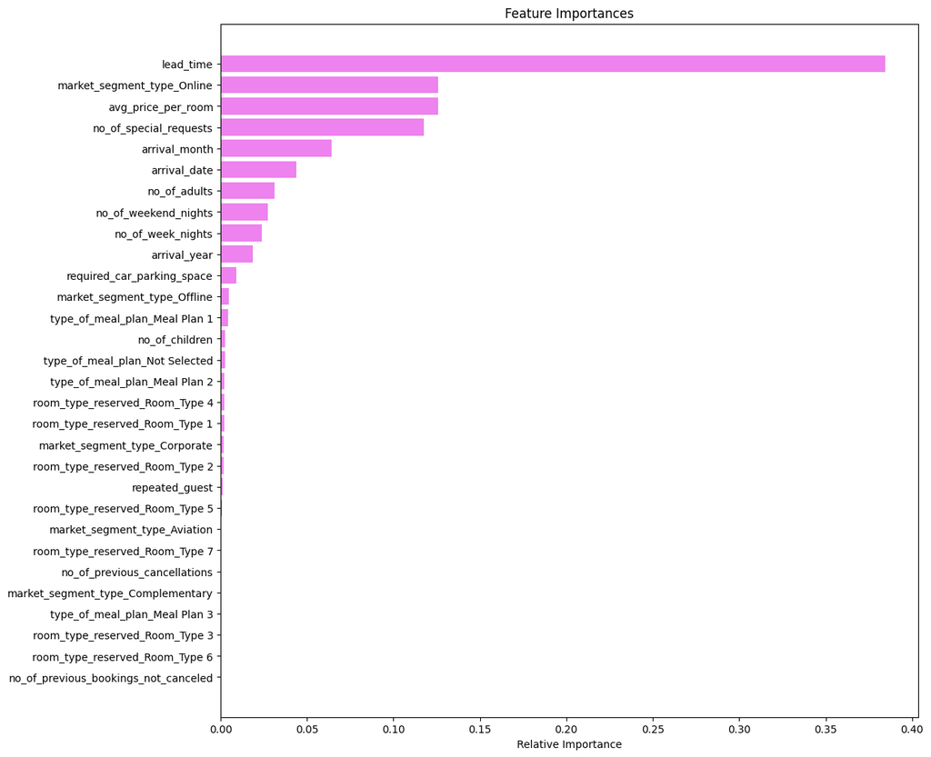

```python
importances = best_model.feature_importances_
indices = np.argsort(importances)

plt.figure(figsize=(12, 12))
plt.title("Feature Importances")
plt.barh(range(len(indices)), importances[indices], color="violet", align="center")
plt.yticks(range(len(indices)), [feature_names[i] for i in indices])
plt.xlabel("Relative Importance")
plt.show()
```

#### Comparing Decision Tree models

```python
# training performance comparison

models_train_comp_df = pd.concat(
    [
        decision_tree_perf_train.T,
        decision_tree_tune_perf_train.T,
        decision_tree_post_perf_train.T,
    ],
    axis=1,
)
models_train_comp_df.columns = [
    "Decision Tree sklearn",
    "Decision Tree (Pre-Pruning)",
    "Decision Tree (Post-Pruning)",
]
print("Training performance comparison:")
models_train_comp_df
```

```
Training performance comparison:
```

[output not shown]

```python
# training performance comparison

models_test_comp_df = pd.concat(
    [
        decision_tree_perf_test.T,
        decision_tree_tune_perf_test.T,
        decision_tree_post_perf_test.T,
    ],
    axis=1,
)
models_test_comp_df.columns = [
    "Decision Tree sklearn",
    "Decision Tree (Pre-Pruning)",
    "Decision Tree (Post-Pruning)",
]
print("Training performance comparison:")
models_test_comp_df
```

```
Training performance comparison:
```

[output not shown]

## Actionable Insights and Recommendations

- What profitable policies for cancellations and refunds can the hotel adopt?
- What other recommedations would you suggest to the hotel?

Regarding cancellation and refund policies, the hotel can have the following options:

- Non-refundable discounts: Offer lower rates for non-refundable bookings to reduce last-minute cancellations.
- Dynamic cancellation fees: Tie fees to lead time, for example, higer penalites for cancellations closer to arrival.
- Segmented policies: Apply stricter policies for high-cancellation segments

Other recomendations for the hotel would be:

- Loyalty programs: incentivize repeat guests with perks like room upgrades to boost retention.
- Personalizes offers: target guests with special requests to enhance satisfaction.
- Price optimization: use machine learning to adjust prices for low-demand periods or high-cancellation segments
- Market focus: Prioritize online channels with tailored promotions while monitoring price sensitivity.

In conclusion, the hotel should leverage data on booking lead times, market segments, and guest preferences to mitigate cancellations and enhance revenue. Implementing dynamic pricing, refining cancellations polices, and fostering repeat guest loyalty will be critical to more profit over the long-term.